# STAT 360: Computational Statistics and Data Analysis

### Load Relevant R Libraries

```r
library(rmarkdown); library(knitr); library(moments);
library(scatterplot3d); library(corrplot); library(pso)
library(psych); library(GPArotation); library(lavaan); library(readxl); library(dplyr)
```

### Matrix Construction

```r
data_matrix_csv <- read.csv("C:/Users/User/OneDrive - University of St. Thomas/Classes/STAT360/STAT360 Project/data/Data Matrix.csv", row.names=1)
life_expectancy <- as.matrix(data_matrix_csv)

col_names_unedited <- c(
  "Life expectancy at birth, total (years)",
  "CO2 emissions (metric tons per capita)",
  "Access to electricity (% of population)",
  "Current health expenditure (% of GDP)",
  "Out-of-pocket expenditure (% of current health expenditure)",
  "Domestic private health expenditure per capita, PPP (current international $)",
  "Domestic general government health expenditure per capita, PPP (current international $)",
  "Renewable internal freshwater resources per capita (cubic meters)",
  "Prevalence of HIV, total (% of population ages 15-49)",
  "Unemployment, total (% of total labor force) (national estimate)",
  "Government Effectiveness: Estimate",
  "Income share held by highest 10%",
  "Prevalence of current tobacco use (% of adults)",
  "Total alcohol consumption per capita (liters of pure alcohol, projected estimates, 15+ years of age)",
  "Political Stability and Absence of Violence/Terrorism: Estimate",
  "Population density (people per sq. km of land area)"
)

# Better for displaying
col_names <- c(
  "Life_expectancy",
  "CO2_emissions",
  "Electricity",
  "Health_expenditure",
  "Out_of_pocket",
  "Private_health_expenditure",
  "Govt_health_expenditure",
  "Freshwater_resources",
  "HIV_prevalence",
  "Unemployment",
  "Govt_effectiveness",
  "Income_share",
  "Tobacco_use",
  "Alcohol_consumption",
  "Political_stability",
  "Population_density"
)

colnames(life_expectancy) <- col_names
```

### Variance-Covariance Matrix

```r
SIGMA <- cov(life_expectancy, use = "pairwise.complete.obs")
SIGMA
```

```
##                            Life_expectancy CO2_emissions Electricity
## Life_expectancy                  56.613599     19.656000   143.90904
## CO2_emissions                    19.656000     21.957050    53.47077
## Electricity                     143.909039     53.470768   600.25600
## Health_expenditure                7.036888      1.901462    20.16410
## Out_of_pocket                   -45.276102    -27.520381   -83.98652
## Private_health_expenditure     2998.698602   1402.368831  6592.53067
## Govt_health_expenditure        7099.652598   3461.022535 14659.67137
## Freshwater_resources          27420.830532  -3207.162537 62163.79862
## HIV_prevalence                  -12.667762     -2.318291   -32.35660
## Unemployment                     -7.344768     -5.174830   -15.24628
## Govt_effectiveness                5.801790      2.442816    14.96731
## Income_share                    -10.354057     -6.177143   -25.58321
## Tobacco_use                      20.834585      2.787175    95.61148
## Alcohol_consumption              11.493254      3.239246    27.62556
## Political_stability               3.952635      1.505941    11.46460
## Population_density             2567.323142    329.437798  4734.90380
##                            Health_expenditure Out_of_pocket
## Life_expectancy                     7.0368878 -4.527610e+01
## CO2_emissions                       1.9014623 -2.752038e+01
## Electricity                        20.1640954 -8.398652e+01
## Health_expenditure                  9.0758757 -1.700235e+01
## Out_of_pocket                     -17.0023465  3.667401e+02
## Private_health_expenditure        937.5047198 -2.023200e+03
## Govt_health_expenditure          2040.0529666 -1.220182e+04
## Freshwater_resources             6400.0362573 -1.133978e+05
## HIV_prevalence                      0.4001537 -2.014671e+01
## Unemployment                        1.0674188 -4.466286e-01
## Govt_effectiveness                  0.9289957 -8.159019e+00
## Income_share                       -1.7383318  1.388092e+01
## Tobacco_use                         7.2202365 -2.657624e+01
## Alcohol_consumption                 2.9649858 -1.592692e+01
## Political_stability                 0.8223059 -9.718820e+00
## Population_density               -555.9827547 -2.308275e+03
##                            Private_health_expenditure Govt_health_expenditure
## Life_expectancy                             2998.6986               7099.6526
## CO2_emissions                               1402.3688               3461.0225
## Electricity                                 6592.5307              14659.6714
## Health_expenditure                           937.5047               2040.0530
## Out_of_pocket                              -2023.2004             -12201.8233
```

[output cut: 64 more lines]

```
## CO2_emissions                    3.294378e+02
## Electricity                      4.734904e+03
## Health_expenditure              -5.559828e+02
## Out_of_pocket                   -2.308275e+03
## Private_health_expenditure       8.181884e+04
## Govt_health_expenditure          2.520139e+05
## Freshwater_resources            -2.534178e+06
## HIV_prevalence                  -1.748864e+02
## Unemployment                    -1.438084e+03
## Govt_effectiveness               3.019097e+02
## Income_share                    -2.062068e+02
## Tobacco_use                      3.017917e+01
## Alcohol_consumption             -2.188422e+02
## Political_stability              3.456291e+02
## Population_density               3.938961e+06
```

### Covariance Matrix (Response/Predictors)

```r
SIGMA_p <- SIGMA[2:16,2:16]
SIGMA_p
```

```
##                            CO2_emissions Electricity Health_expenditure
## CO2_emissions                  21.957050    53.47077          1.9014623
## Electricity                    53.470768   600.25600         20.1640954
## Health_expenditure              1.901462    20.16410          9.0758757
## Out_of_pocket                 -27.520381   -83.98652        -17.0023465
## Private_health_expenditure   1402.368831  6592.53067        937.5047198
## Govt_health_expenditure      3461.022535 14659.67137       2040.0529666
## Freshwater_resources        -3207.162537 62163.79862       6400.0362573
## HIV_prevalence                 -2.318291   -32.35660          0.4001537
## Unemployment                   -5.174830   -15.24628          1.0674188
## Govt_effectiveness              2.442816    14.96731          0.9289957
## Income_share                   -6.177143   -25.58321         -1.7383318
## Tobacco_use                     2.787175    95.61148          7.2202365
## Alcohol_consumption             3.239246    27.62556          2.9649858
## Political_stability             1.505941    11.46460          0.8223059
## Population_density            329.437798  4734.90380       -555.9827547
##                            Out_of_pocket Private_health_expenditure
## CO2_emissions              -2.752038e+01                  1402.3688
## Electricity                -8.398652e+01                  6592.5307
## Health_expenditure         -1.700235e+01                   937.5047
## Out_of_pocket               3.667401e+02                 -2023.2004
## Private_health_expenditure -2.023200e+03                467350.7680
## Govt_health_expenditure    -1.220182e+04                606905.1703
## Freshwater_resources       -1.133978e+05                 80433.4890
## HIV_prevalence             -2.014671e+01                  -464.1102
## Unemployment               -4.466286e-01                  -500.0547
## Govt_effectiveness         -8.159019e+00                   416.1200
## Income_share                1.388092e+01                  -510.8805
## Tobacco_use                -2.657624e+01                   998.9118
## Alcohol_consumption        -1.592692e+01                  1088.5776
## Political_stability        -9.718820e+00                   223.1083
## Population_density         -2.308275e+03                 81818.8445
##                            Govt_health_expenditure Freshwater_resources
## CO2_emissions                            3461.0225        -3.207163e+03
## Electricity                             14659.6714         6.216380e+04
## Health_expenditure                       2040.0530         6.400036e+03
## Out_of_pocket                          -12201.8233        -1.133978e+05
## Private_health_expenditure             606905.1703         8.043349e+04
## Govt_health_expenditure               1913107.4928         8.820802e+06
## Freshwater_resources                  8820802.0892         2.036196e+09
```

[output cut: 41 more lines]

```
## CO2_emissions                       1.50594139       3.294378e+02
## Electricity                        11.46460215       4.734904e+03
## Health_expenditure                  0.82230593      -5.559828e+02
## Out_of_pocket                      -9.71881976      -2.308275e+03
## Private_health_expenditure        223.10829419       8.181884e+04
## Govt_health_expenditure           687.20389160       2.520139e+05
## Freshwater_resources             7230.45946128      -2.534178e+06
## HIV_prevalence                      0.03476909      -1.748864e+02
## Unemployment                       -1.21462410      -1.438084e+03
## Govt_effectiveness                  0.72148389       3.019097e+02
## Income_share                       -1.90093069      -2.062068e+02
## Tobacco_use                         1.83390009       3.017917e+01
## Alcohol_consumption                 1.73172224      -2.188422e+02
## Political_stability                 1.00018271       3.456291e+02
## Population_density                345.62908802       3.938961e+06
```

```r
SIGMA_r  <- SIGMA[1,1]
SIGMA_r  <- as.matrix(SIGMA_r)
SIGMA_r
```

```
##         [,1]
## [1,] 56.6136
```

### Correlation Matrix (Predictor/Response)

```r
R_p <- (solve(sqrt(diag(diag(SIGMA_p))))) %*% SIGMA_p %*%
t(solve(sqrt(diag(diag(SIGMA_p)))))
dimnames(R_p) <- list(c("CO2_emissions", "Electricity", "Health_expenditure", "Out_of_pocket", "Private_health_expenditure",
  "Govt_health_expenditure","Freshwater_resources","HIV_prevalence","Unemployment", "Govt_effectiveness",
  "Income_share","Tobacco_use","Alcohol_consumption", "Political_stability", "Population_density"),
c("CO2_emissions", "Electricity", "Health_expenditure", "Out_of_pocket", "Private_health_expenditure", "Govt_health_expenditure",
  "Freshwater_resources", "HIV_prevalence", "Unemployment", "Govt_effectiveness", "Income_share", "Tobacco_use",
  "Alcohol_consumption","Political_stability", "Population_density"))
R_p
```

```
##                            CO2_emissions Electricity Health_expenditure
## CO2_emissions                 1.00000000  0.46575891         0.13469655
## Electricity                   0.46575891  1.00000000         0.27319089
## Health_expenditure            0.13469655  0.27319089         1.00000000
## Out_of_pocket                -0.30668199 -0.17900377        -0.29470359
## Private_health_expenditure    0.43777784  0.39360665         0.45520572
## Govt_health_expenditure       0.53400798  0.43259978         0.48958430
## Freshwater_resources         -0.01516786  0.05622889         0.04707913
## HIV_prevalence               -0.11854103 -0.31643340         0.03182513
## Unemployment                 -0.21321433 -0.12014420         0.06840657
## Govt_effectiveness            0.52485479  0.61505096         0.31045946
## Income_share                 -0.25819392 -0.20451827        -0.11301440
## Tobacco_use                   0.06023004  0.39516427         0.24268505
## Alcohol_consumption           0.17394230  0.28372072         0.24764330
## Political_stability           0.32135229  0.46789786         0.27292887
## Population_density            0.03542384  0.09737603        -0.09298785
##                            Out_of_pocket Private_health_expenditure
## CO2_emissions               -0.306681993                0.437777843
## Electricity                 -0.179003767                0.393606646
## Health_expenditure          -0.294703586                0.455205721
## Out_of_pocket                1.000000000               -0.154539057
## Private_health_expenditure  -0.154539057                1.000000000
## Govt_health_expenditure     -0.460655088                0.641844273
## Freshwater_resources        -0.131224750                0.002607388
## HIV_prevalence              -0.252065082               -0.162662457
## Unemployment                -0.004502717               -0.141222299
## Govt_effectiveness          -0.428937758                0.612819570
## Income_share                 0.141966077               -0.146367028
## Tobacco_use                 -0.140523917                0.147959051
## Alcohol_consumption         -0.209267115                0.400669390
## Political_stability         -0.507451668                0.326328169
## Population_density          -0.060731989                0.060303293
##                            Govt_health_expenditure Freshwater_resources
## CO2_emissions                            0.5340080         -0.015167857
## Electricity                              0.4325998          0.056228895
## Health_expenditure                       0.4895843          0.047079129
## Out_of_pocket                           -0.4606551         -0.131224750
## Private_health_expenditure               0.6418443          0.002607388
## Govt_health_expenditure                  1.0000000          0.141328142
## Freshwater_resources                     0.1413281          1.000000000
```

[output cut: 41 more lines]

```
## CO2_emissions                      0.321352294        0.035423837
## Electricity                        0.467897863        0.097376032
## Health_expenditure                 0.272928871       -0.092987852
## Out_of_pocket                     -0.507451668       -0.060731989
## Private_health_expenditure         0.326328169        0.060303293
## Govt_health_expenditure            0.496793898        0.091804496
## Freshwater_resources               0.160219909       -0.028296754
## HIV_prevalence                     0.008329928       -0.021113139
## Unemployment                      -0.234481992       -0.139894553
## Govt_effectiveness                 0.726310723        0.153151648
## Income_share                      -0.372281948       -0.020349673
## Tobacco_use                        0.185682881        0.001539757
## Alcohol_consumption                0.435699241       -0.027745239
## Political_stability                1.000000000        0.174132479
## Population_density                 0.174132479        1.000000000
```

```r
R_r <- cor(SIGMA_r, use = "pairwise.complete.obs")
R_r
```

```
##      [,1]
## [1,]   NA
```

### Eigenvalues for response/predictor

```r
predictor <- eigen(R_p)$values
predictor
```

```
##  [1] 4.82235433 1.63890455 1.39841899 1.18562862 1.04308940 0.96650885
##  [7] 0.86493263 0.73485866 0.66266370 0.42142900 0.39900019 0.37160620
## [13] 0.24974275 0.14573850 0.09512362
```

### Intrinsic Dimensionality: Predictors

```r
sum(eigen(R_p)$values>1.0)
```

```
## [1] 5
```

```r
sum(eigen(R_p)$values>0.7)
```

```
## [1] 8
```

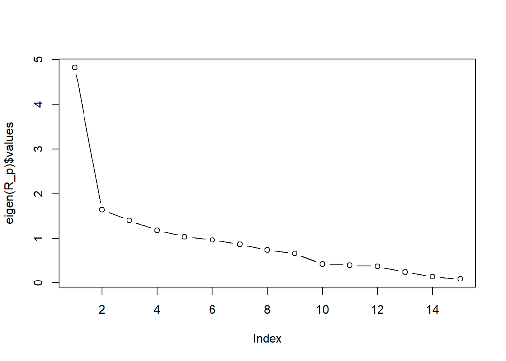

```r
plot(eigen(R_p)$values, type = "b")
```

For Kaiser’s criterion, 5 values are retained since only 5 values are above 1.

For Jolliffe’s criterion, 8 values are retained because they are above the threshold of 0.7.

We think that Kaiser’s criterion and Jolliffe’s criterion represents our dimensionality the best. The average of these is 6.5, which we will round to an intrinsic dimensionality of 7.

### Intrinsic Dimensionality: Response

Since we only have a since response dimension are intrinsic dimensionality will be 1 no matter what criterion is applied.

### Rotated Loading Matrix: Orthogonal

```r
A <- pca(r = R_p, nfactors = 7, rotate = "varimax")$loadings[]
A
```

```
##                                     RC1         RC4           RC6          RC2
## CO2_emissions               0.838863469  0.15655189  0.0250232501 -0.186141974
## Electricity                 0.513183429  0.35953960 -0.0224677469 -0.279170326
## Health_expenditure          0.082302220  0.78090107  0.0666188458  0.201506319
## Out_of_pocket              -0.647539853 -0.05834038 -0.1551741701 -0.464377555
## Private_health_expenditure  0.294858420  0.78579417  0.2089348629 -0.194018364
## Govt_health_expenditure     0.531525704  0.52508965  0.4606357946 -0.114325812
## Freshwater_resources        0.020561709  0.03065211  0.0006122306 -0.085187608
## HIV_prevalence             -0.005978193 -0.09723961  0.1249349452  0.856226022
## Unemployment               -0.224721202  0.12602433 -0.2887392784  0.686701478
## Govt_effectiveness          0.631623417  0.39841327  0.4455757991 -0.142494502
## Income_share               -0.195819426  0.10642848 -0.7015406305  0.066027268
## Tobacco_use                 0.022878027  0.09670803  0.1679373941 -0.005447113
## Alcohol_consumption         0.063461299  0.36201641  0.7776371656  0.045564988
## Political_stability         0.543312666  0.13817200  0.4744371596  0.048291089
## Population_density          0.041983359 -0.02036066 -0.0070765113 -0.048971079
##                                     RC3         RC5           RC7
## CO2_emissions              -0.012699993 -0.19780021 -0.1090446216
## Electricity                 0.481598350  0.07059113  0.1296169655
## Health_expenditure          0.195517869  0.12444446 -0.0785017889
## Out_of_pocket              -0.061688755 -0.27959349 -0.0871601818
## Private_health_expenditure -0.048708961 -0.11954524  0.0525814408
## Govt_health_expenditure     0.033591766  0.08732441  0.0222214798
## Freshwater_resources       -0.060820052  0.92261949 -0.0565467485
## HIV_prevalence             -0.245676004 -0.07897422  0.0236646026
## Unemployment                0.242474018 -0.06653961 -0.1479993671
## Govt_effectiveness          0.094975286  0.09725086  0.1945884382
## Income_share               -0.485358948  0.14303710  0.0731714592
## Tobacco_use                 0.909030697 -0.04828197  0.0005949483
## Alcohol_consumption         0.014501672  0.03910762 -0.0127114543
## Political_stability         0.152541291  0.29487405  0.2823518120
## Population_density          0.001777788 -0.05475001  0.9592584002
```

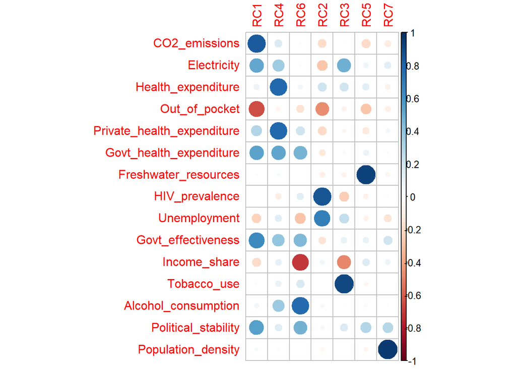

```r
corrplot(A)
```

### Rotated Loading Matrix: Oblique

```r
A_1 <- pca(r = R_p, nfactors = 7, rotate = "oblimin")$loadings[]
A_1
```

```
##                                    TC7         TC1         TC6          TC2
## CO2_emissions               0.91292105  0.06824601 -0.04368914 -0.070692456
## Electricity                 0.43810561  0.26430140 -0.14527759 -0.246144418
## Health_expenditure         -0.08143382  0.80039874 -0.06493078  0.162009475
## Out_of_pocket              -0.55495965  0.02503986 -0.03992621 -0.557601765
## Private_health_expenditure  0.15798584  0.79759735  0.10827996 -0.165090703
## Govt_health_expenditure     0.36178028  0.47121841  0.36456718 -0.035018485
## Freshwater_resources       -0.12053484 -0.02095155 -0.04080737 -0.089934349
## HIV_prevalence             -0.03105566 -0.04884959  0.10928640  0.876910548
## Unemployment               -0.20104884  0.17425831 -0.34337380  0.601571582
## Govt_effectiveness          0.45680440  0.31836595  0.34101473 -0.039168821
## Income_share               -0.09429021  0.18547755 -0.71740121  0.027917919
## Tobacco_use                -0.06363029  0.02228116  0.10566238 -0.058676563
## Alcohol_consumption        -0.16097971  0.35973429  0.75958810  0.080508193
## Political_stability         0.34141558  0.04334593  0.38121050  0.148706222
## Population_density         -0.11208442 -0.02373132 -0.06822284  0.007060591
##                                     TC3         TC5         TC4
## CO2_emissions              -0.055741399 -0.15950296 -0.10425962
## Electricity                 0.450325302  0.09461502  0.14154164
## Health_expenditure          0.180220891  0.10033562 -0.07988782
## Out_of_pocket              -0.077097205 -0.28834776 -0.08084324
## Private_health_expenditure -0.111624503 -0.12434116  0.05774399
## Govt_health_expenditure    -0.027237273  0.10459421  0.01893359
## Freshwater_resources       -0.050869867  0.94342928 -0.08095606
## HIV_prevalence             -0.195333118 -0.11773996  0.01702314
## Unemployment                0.306808747 -0.11039307 -0.14656897
## Govt_effectiveness          0.038470457  0.12007778  0.19633490
## Income_share               -0.447761837  0.11821412  0.07285263
## Tobacco_use                 0.910329164 -0.04302551  0.01263035
## Alcohol_consumption        -0.038004530  0.03788881 -0.02199420
## Political_stability         0.125065796  0.31531745  0.27996805
## Population_density          0.006382124 -0.07516463  0.98504437
```

```r
F_1 <- pca(r = R_p, nfactors = 7, rotate = "oblimin")$Phi
F_1
```

```
##             TC7          TC1         TC6          TC2          TC3        TC5
## TC7  1.00000000  0.311026653  0.30493317 -0.092059528  0.123704638 0.15510938
## TC1  0.31102665  1.000000000  0.22001416 -0.001240454  0.155344528 0.13779566
## TC6  0.30493317  0.220014162  1.00000000 -0.017428959  0.155290960 0.09355230
## TC2 -0.09205953 -0.001240454 -0.01742896  1.000000000 -0.001664951 0.03276992
## TC3  0.12370464  0.155344528  0.15529096 -0.001664951  1.000000000 0.01162580
## TC5  0.15510938  0.137795661  0.09355230  0.032769923  0.011625804 1.00000000
## TC4  0.19865602  0.067611664  0.13001281 -0.058940602  0.010842147 0.07899436
##             TC4
## TC7  0.19865602
## TC1  0.06761166
## TC6  0.13001281
## TC2 -0.05894060
## TC3  0.01084215
## TC5  0.07899436
## TC4  1.00000000
```

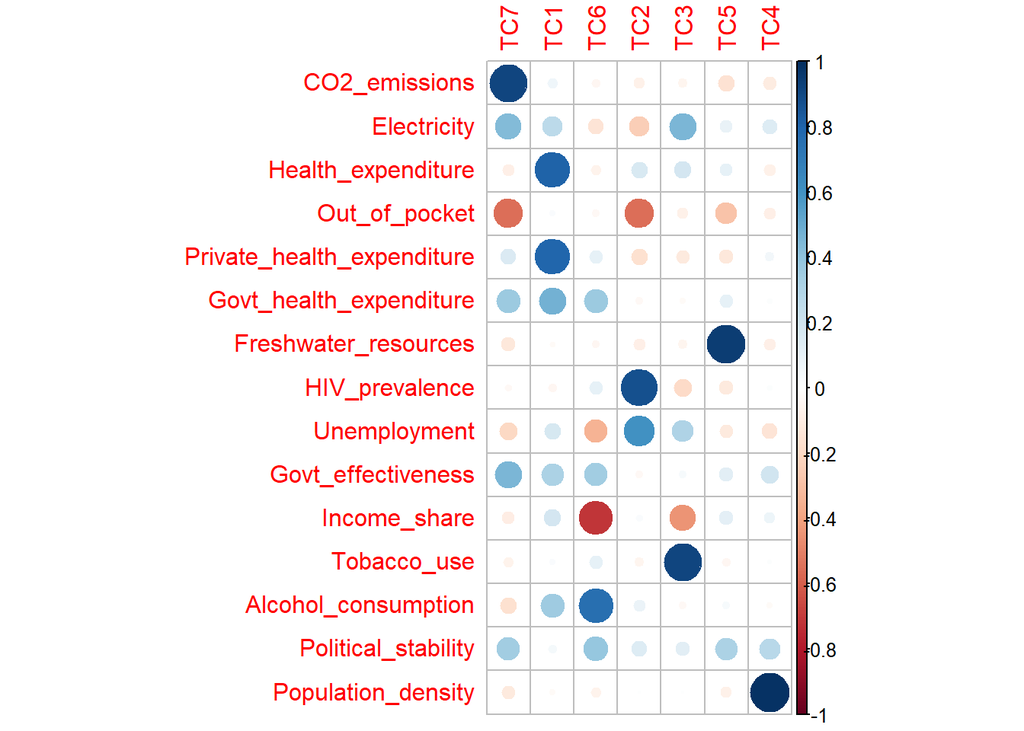

```r
corrplot(A_1)
```

There are correlations among factors above 0.3 , so oblique rotation is indeed necessary.

### Communality

```r
pca(r = R_p, nfactors = 7, rotate = "oblimin")$communality
```

```
##              CO2_emissions                Electricity
##                  0.8146524                  0.7247875
##         Health_expenditure              Out_of_pocket
##                  0.7214992                  0.7520119
## Private_health_expenditure    Govt_health_expenditure
##                  0.8051393                  0.7927422
##       Freshwater_resources             HIV_prevalence
##                  0.8667430                  0.8253767
##               Unemployment         Govt_effectiveness
##                  0.7064360                  0.8328664
##               Income_share                Tobacco_use
##                  0.8075781                  0.8667768
##        Alcohol_consumption        Political_stability
##                  0.7437802                  0.7316449
##         Population_density
##                  0.9278028
```

For a seven factor solution, all the dimensions retain above 70% of the variance of the original dimensions. This is a good because we avoid excessive data loss.

### Variance

```r
pca(r = R_p, nfactors = 7, rotate = "oblimin")
```

```
## Principal Components Analysis
## Call: principal(r = r, nfactors = nfactors, residuals = residuals,
##     rotate = rotate, n.obs = n.obs, covar = covar, scores = scores,
##     missing = missing, impute = impute, oblique.scores = oblique.scores,
##     method = method, use = use, cor = cor, correct = 0.5, weight = NULL)
## Standardized loadings (pattern matrix) based upon correlation matrix
##                              TC7   TC1   TC6   TC2   TC3   TC5   TC4   h2    u2
## CO2_emissions               0.91  0.07 -0.04 -0.07 -0.06 -0.16 -0.10 0.81 0.185
## Electricity                 0.44  0.26 -0.15 -0.25  0.45  0.09  0.14 0.72 0.275
## Health_expenditure         -0.08  0.80 -0.06  0.16  0.18  0.10 -0.08 0.72 0.279
## Out_of_pocket              -0.55  0.03 -0.04 -0.56 -0.08 -0.29 -0.08 0.75 0.248
## Private_health_expenditure  0.16  0.80  0.11 -0.17 -0.11 -0.12  0.06 0.81 0.195
## Govt_health_expenditure     0.36  0.47  0.36 -0.04 -0.03  0.10  0.02 0.79 0.207
## Freshwater_resources       -0.12 -0.02 -0.04 -0.09 -0.05  0.94 -0.08 0.87 0.133
## HIV_prevalence             -0.03 -0.05  0.11  0.88 -0.20 -0.12  0.02 0.83 0.175
## Unemployment               -0.20  0.17 -0.34  0.60  0.31 -0.11 -0.15 0.71 0.294
## Govt_effectiveness          0.46  0.32  0.34 -0.04  0.04  0.12  0.20 0.83 0.167
## Income_share               -0.09  0.19 -0.72  0.03 -0.45  0.12  0.07 0.81 0.192
## Tobacco_use                -0.06  0.02  0.11 -0.06  0.91 -0.04  0.01 0.87 0.133
## Alcohol_consumption        -0.16  0.36  0.76  0.08 -0.04  0.04 -0.02 0.74 0.256
## Political_stability         0.34  0.04  0.38  0.15  0.13  0.32  0.28 0.73 0.268
## Population_density         -0.11 -0.02 -0.07  0.01  0.01 -0.08  0.99 0.93 0.072
##                            com
## CO2_emissions              1.1
## Electricity                3.8
## Health_expenditure         1.3
## Out_of_pocket              2.6
## Private_health_expenditure 1.3
## Govt_health_expenditure    3.0
## Freshwater_resources       1.1
## HIV_prevalence             1.2
## Unemployment               2.9
## Govt_effectiveness         3.4
## Income_share               2.0
## Tobacco_use                1.1
## Alcohol_consumption        1.6
## Political_stability        4.5
## Population_density         1.0
##
##                        TC7  TC1  TC6  TC2  TC3  TC5  TC4
## SS loadings           2.25 2.14 1.93 1.61 1.52 1.25 1.22
## Proportion Var        0.15 0.14 0.13 0.11 0.10 0.08 0.08
## Cumulative Var        0.15 0.29 0.42 0.53 0.63 0.71 0.79
## Proportion Explained  0.19 0.18 0.16 0.13 0.13 0.11 0.10
## Cumulative Proportion 0.19 0.37 0.53 0.67 0.79 0.90 1.00
##
##  With component correlations of
##       TC7  TC1   TC6   TC2  TC3  TC5   TC4
## TC7  1.00 0.31  0.30 -0.09 0.12 0.16  0.20
## TC1  0.31 1.00  0.22  0.00 0.16 0.14  0.07
## TC6  0.30 0.22  1.00 -0.02 0.16 0.09  0.13
## TC2 -0.09 0.00 -0.02  1.00 0.00 0.03 -0.06
## TC3  0.12 0.16  0.16  0.00 1.00 0.01  0.01
## TC5  0.16 0.14  0.09  0.03 0.01 1.00  0.08
## TC4  0.20 0.07  0.13 -0.06 0.01 0.08  1.00
##
## Mean item complexity =  2.1
## Test of the hypothesis that 7 components are sufficient.
##
## The root mean square of the residuals (RMSR) is  0.06
##
## Fit based upon off diagonal values = 0.95
```